# Skills Development for Adolescent Girls

Investment case · East Java, Indonesia

Hernando Grueso, PhD · UNICEF

2026-07-01

## Contents

**1 · Diagnostic** — scale & profile of the gap (NEET, child marriage, early pregnancy, poverty)

**2 · Evidence → Theory of Change** — what works, and how it maps to Double Track

**3 · Projections** — returns to education (wage & consumption based)

**4 · Costing & ROI** — component costs, benefit value chain, BCR

**5 · Key Findings** — the analysis in one slide

**6 · Methods & Data** — sample, data-availability plan, transportability method, Mincer specification

# 1 · Diagnostic — scale & profile of the gap

## The gap is in the transition, not the classroom

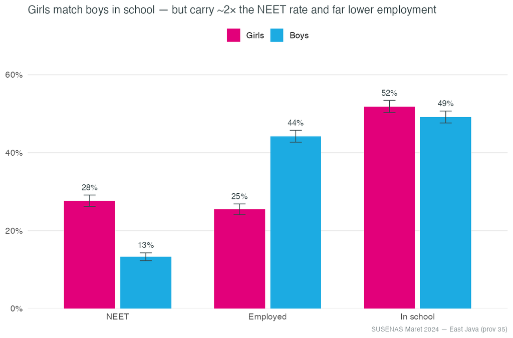

## Outcomes by area of residence

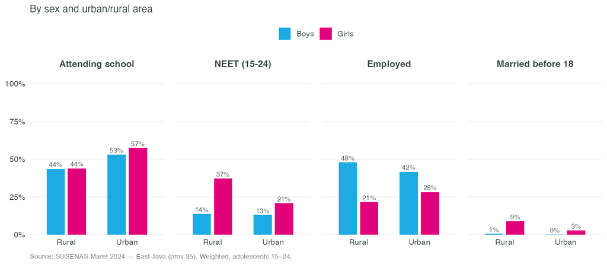

## Where NEET concentrates — by district

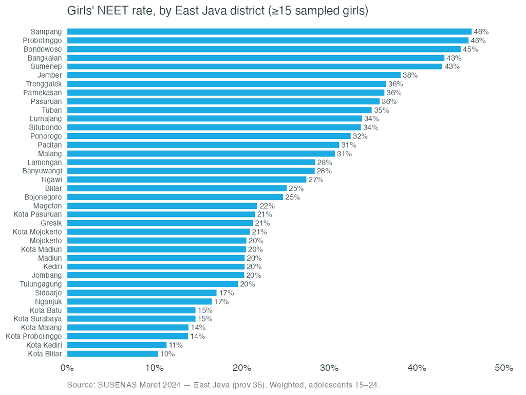

SUSENAS Maret 2024, girls 15–24, survey-weighted; East Java districts with ≥15 sampled girls.

## Outcomes by per-capita expenditure quintile

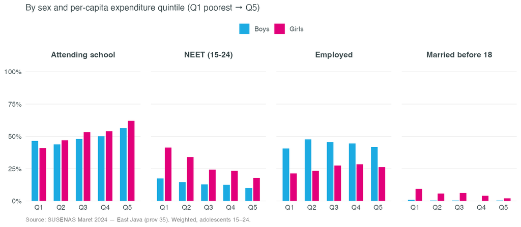

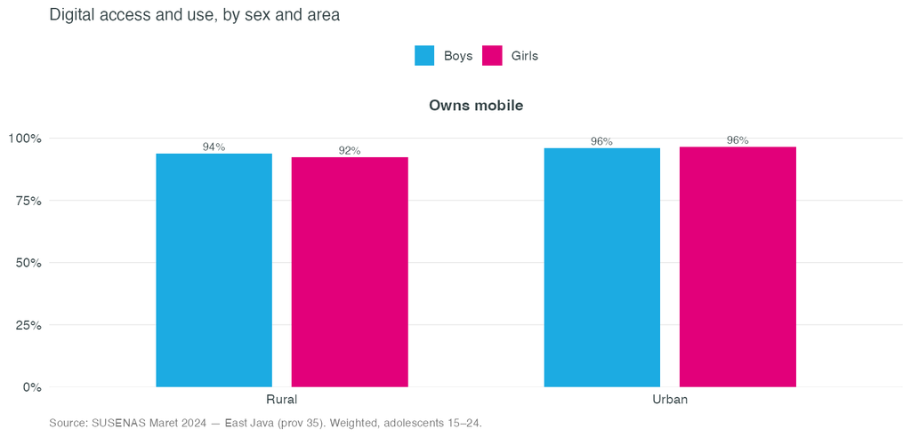

## Child marriage — a pathway into exclusion

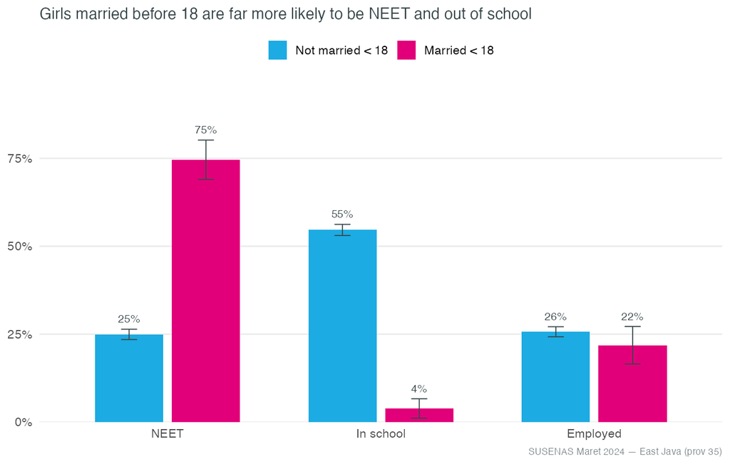

Girls 15–24, SUSENAS Maret 2024, survey-weighted (95% CIs). Girls married before 18 are far more likely to be NEET and out of school. **Association, not causal** — direction is not identified (marriage and leaving school are mutually reinforcing). 5.4% of East-Java girls 15–24 married before 18 (vs 0.4% of boys), from the household roster’s age-at-first-marriage question.

## Early pregnancy — the twin pathway

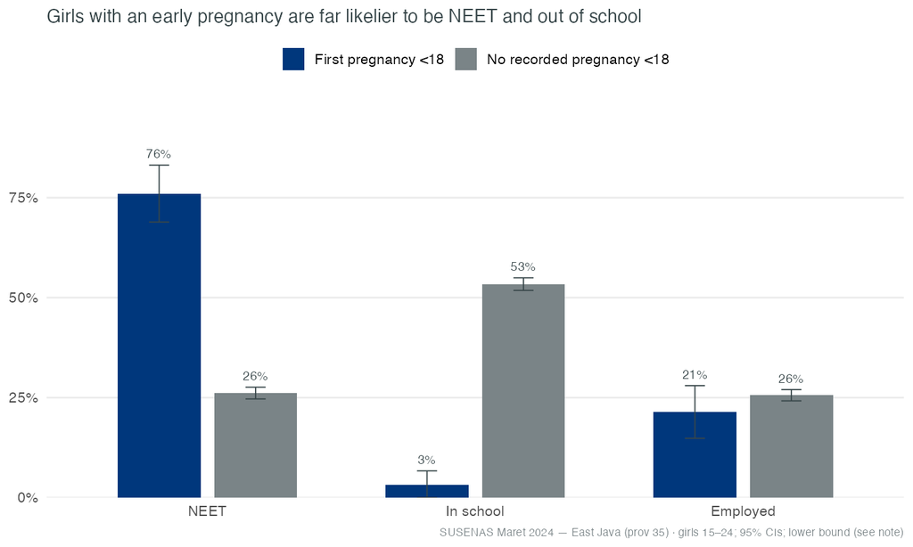

First pregnancy before 18 (SUSENAS Blok XV). Early pregnancy and child marriage are tightly sequenced — pregnancy often precipitates marriage under social pressure. SUSENAS records pregnancies only for ever-married women, so these are **lower-bound** estimates.

## Poverty drives child marriage

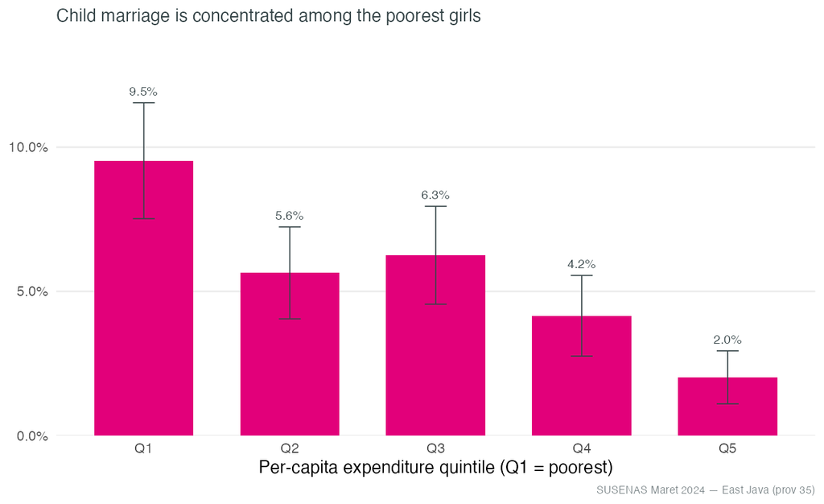

Child marriage falls steeply from the poorest to the richest expenditure quintile — the mechanism a cash-transfer (Cash+) component is designed to interrupt. Indonesia’s own PKH cut girls’ child marriage by ~3.5pp (Priebe & Sumarto, 2025).

## Poverty also drives early pregnancy

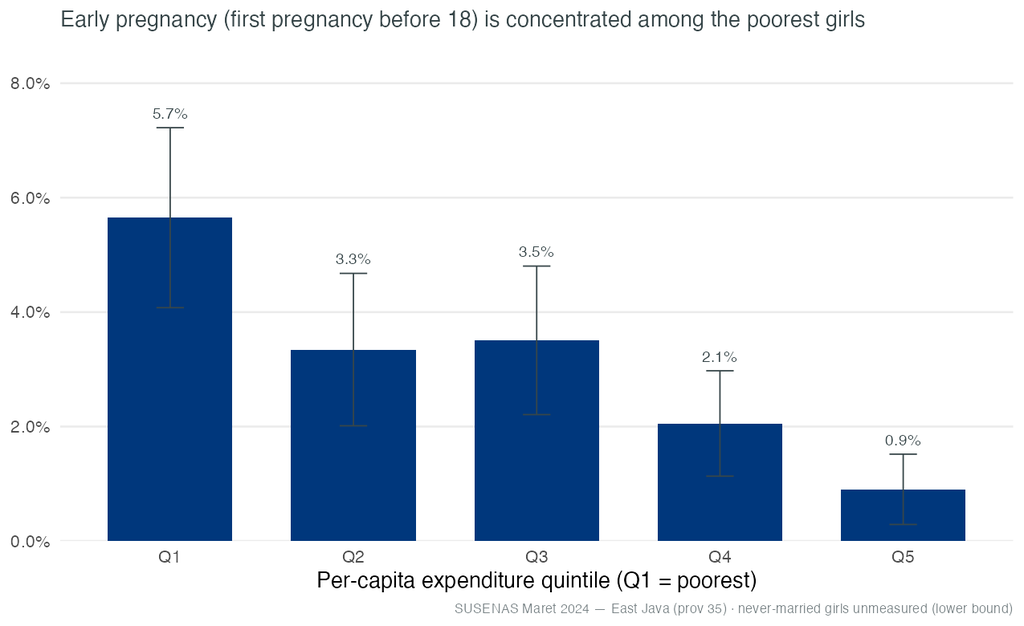

The same poverty gradient as child marriage — one mechanism, two manifestations. This is the entry point for a **Cash+ component**: PKH reduced girls’ child marriage by ~3.5pp (Priebe & Sumarto, 2025).

## Formal tests — marriage, pregnancy, poverty & exclusion

| Hypothesis | Effect (pp) | SE | p |
| --- | --- | --- | --- |
| Poverty (Q1–Q2) → child marriage | 2.6 | 0.8 | 0.0011 |
| Child marriage → NEET | 36.5 | 3.2 | 0.0000 |
| Child marriage → in school | -29.8 | 2.4 | 0.0000 |
| Child marriage → employment | -12.0 | 3.1 | 0.0001 |
| Poverty × child marriage (NEET amplification) | -8.7 | 6.2 | 0.1580 |
| Poverty (Q1–Q2) → early pregnancy | 2.1 | 0.6 | 0.0009 |
| Early pregnancy → NEET | 36.7 | 4.2 | 0.0000 |
| Early pregnancy → in school | -29.3 | 3.0 | 0.0000 |
| Early pregnancy → employment | -12.6 | 3.6 | 0.0006 |
| Early pregnancy ↔︎ child marriage (association) | 95.9 | 0.5 | 0.0000 |
| Poverty × early pregnancy (NEET amplification) | -3.7 | 8.3 | 0.6510 |

Linear-probability estimates, girls 15–24, survey-weighted, PSU-clustered, N ≈ 6,100–6,200 per model (SUSENAS Maret 2024). Effects in percentage points. **Controls**: models of marriage/pregnancy → outcomes include age, urban/rural, and per-capita-expenditure poverty (Q1–Q2); models of poverty → marriage/pregnancy, and the two interaction terms, include age and urban/rural. Robust to adding **district fixed effects**. Poverty raises the risk of both marriage and pregnancy, and marriage/pregnancy independently predict much higher NEET — but the **poverty × marriage/pregnancy interaction is not statistically significant** (p=0.16 and p=0.65), so the data do not support an amplified penalty specifically for poor girls; the case for pairing skills programming with cash transfers rests on the poverty→marriage/pregnancy pathway itself, reinforced by PKH’s own child-marriage evidence. Association, not causal identification.

## Target population — adolescent girls 15–24

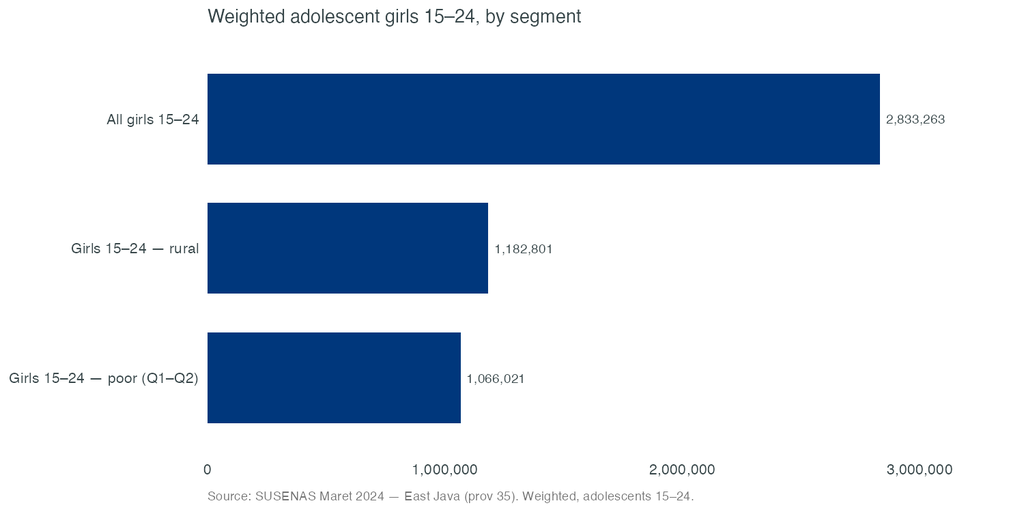

# 2 · Evidence → Theory of Change

## What works — best-matched evidence (raw)

| Programme | Design | Girls / age | Focus | Key result | Fit for East Java |
| --- | --- | --- | --- | --- | --- |
| Adolescent girls’ wellbeing — Bergström & Özler 2021 | Review (104 studies) | Adolescent girls | Multi-sector interventions | Integrated packages beat single-sector ones | Synthesis backbone for the ToC |
| NEET in Indonesia — Faizah, Isbah & Azca 2025 | Qualitative | Youth (gendered) | Drivers of girls’ NEET | Non-education factors (norms, care, marriage) drive girls’ NEET | Indonesia-specific NEET context |
| ELA girls’ clubs — Bandiera 2018 (Sierra Leone) | RCT | Girls 12–25 | Vocational + life skills | Enrolment +8.5pp; more income-generating activity | Closest Skills4Girls-in-Double-Track model |
| Female digital-employment bootcamp — Alzúa 2020 (Argentina/Colombia) | RCT | Women 18–50 | Coding for employment | Large coding-skill gains | Core digital-skills → jobs arm |
| Irumi — Näslund-Hadley 2025 (Paraguay) | RCT | Pupils | Computational thinking | +0.09 SD CT | Structured CT pedagogy |
| Robotics & Coding — Gülen 2025 (Turkey) | RCT | Girls 14–16 | Robotics / coding | Higher STEM-career orientation | Girls’ STEM, secondary age |
| Samata — Prakash 2019 (India) | RCT | Poor girls 13–16 | Secondary-transition support | More girls transition; norm shift | South Asia; senior-secondary transition |
| Room to Read GEP — Edmonds 2021 (India) | RCT | Girls | Life skills + mentoring | Dropout −3.5 to −4.1pp | Mentoring/pedagogy layer cuts dropout |
| Negotiating a Better Future — Ashraf 2025 (Zambia) | RCT | Girls ~14 | Negotiation skills | +0.26 years schooling (10-yr) | Durable, cheap soft-skills layer |
| OLPC / Plan Ceibal — de Melo 2014 (Uruguay) | Quasi / review | Pupils | Laptops (hardware-led) | Learning ≈ null (−0.05 SD) | Caution: hardware alone fails → fund pedagogy |

## Theory of change — skills for girls → lower NEET

```
flowchart LR
  A1["Digital &amp; 21st-C skills<br/>content + connectivity"]:::a
  A2["Girls-responsive pedagogy<br/>teacher training + mentoring"]:::b
  A3["Ancillary supports<br/>marriage-delay, flexible<br/>learning, safe spaces"]:::c
  O1["Skills acquired<br/>digital · STEM · socio-emotional"]:::o
  O2["Stay enrolled,<br/>complete senior secondary"]:::o
  M1["Transition to<br/>higher ed / work"]:::o
  R["Lower NEET ·<br/>narrower gender gap"]:::r
  I["Higher lifetime earnings ·<br/>productivity → 2045 Vision"]:::r
  A1 --> O1
  A2 --> O1
  A2 --> O2
  A3 --> O2
  O1 --> M1
  O2 --> M1
  M1 --> R --> I
  classDef a fill:#eaf6fc,stroke:#1CABE2,color:#00377C
  classDef b fill:#fde9f2,stroke:#E2007A,color:#a3005a
  classDef c fill:#f4f4f4,stroke:#999,color:#555
  classDef o fill:#fff7e6,stroke:#FFC20E,color:#7a5b00
  classDef r fill:#e8f5e9,stroke:#2e7d32,color:#1b5e20
```

Embedded in Double Track / *Tambahan Keterampilan*. Evidence: ELA → O2/M1; Alzúa/Irumi/Gülen → O1/M1; Room to Read/Negotiating → O2 (pedagogy layer); OLPC → caution on hardware-led A1. Measured against the ToR: cost per NEET averted, transition to HE/work, BCR/NPV.

## Raw effect → anchored effect

| Programme | Raw effect (95% CI) | φpop | φgeo | φecon | φdeliv | Adjusted (95% CI) | Sig |
| --- | --- | --- | --- | --- | --- | --- | --- |
| ELA girls’ clubs (Bandiera 2018) — SLE | +0.085 [-0.011, +0.181] pp | 0.95 | 0.65 | 0.80 | 0.70 | +0.029 [-0.004, +0.063] | — |
| Female coding bootcamp (Alzúa 2020) — Arg./Col. | +1.080 [+0.719, +1.441] score-SD | 0.70 | 0.50 | 0.85 | 0.70 | +0.225 [+0.150, +0.300] | ✓ |
| Negotiation skills (Ashraf 2025) — ZMB | +0.264 [+0.041, +0.487] yrs | 0.90 | 0.65 | 0.80 | 0.70 | +0.086 [+0.013, +0.160] | ✓ |
| Room to Read GEP (Edmonds 2021) — IND | -0.035 [-0.070, +0.000] pp dropout | 0.95 | 0.85 | 0.90 | 0.70 | -0.018 [-0.036, +0.000] | — |
| Irumi comp. thinking (Näslund-Hadley 2025) — PRY | +0.089 [-0.013, +0.191] SD | 0.80 | 0.50 | 0.85 | 0.70 | +0.021 [-0.003, +0.045] | — |

# 3 · Projections — East Java

## Returns to schooling — girls vs boys (wage-based)

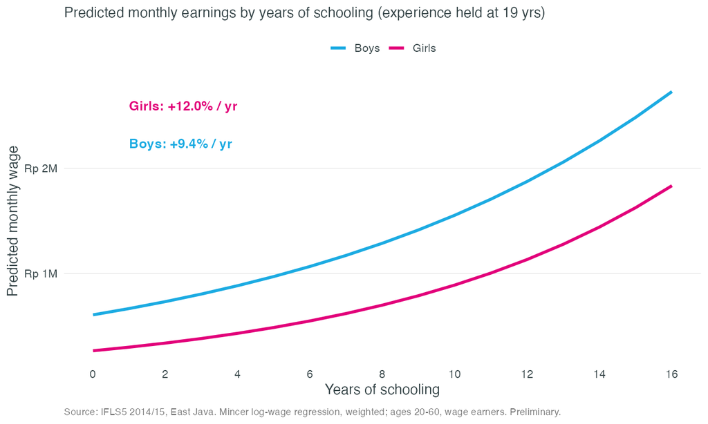

Earnings are **not collected in SUSENAS KOR**, so the Mincer return is estimated on **IFLS5 (2014/15)** wage earners 20–60 and applied to East Java. Raw return; girls +12.0%/yr, boys +9.4%/yr — entered into the cost-benefit at a selection-bounded **7–12%** range. Refine with Sakernas East-Java wages.

## Predicted consumption by schooling — girls vs boys

Since SUSENAS collects no wages, we estimate the **welfare return to schooling** using household **per-capita consumption** (`KAPITA`) — adults 25–54, survey-weighted, PSU-clustered, same quadratic specification as the Mincer equation below, so the curve is **model-based and age-adjusted**.

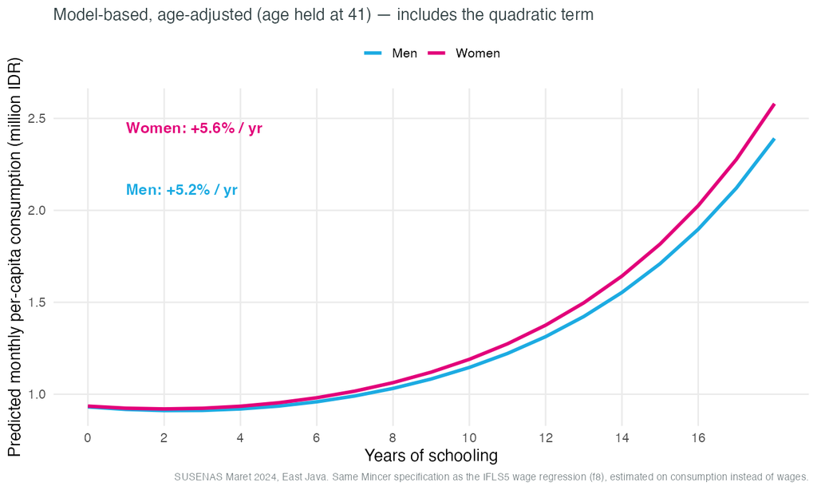

Fitted values from the by-sex regression, age held at the sample mean — girls’ return is again slightly above boys’, consistent with the wage-based estimate.

## Returns to education — consumption-based (SUSENAS 2024), the estimates

| Model | Term | Estimate | SE | p |
| --- | --- | --- | --- | --- |
| Overall (linear) | years_school | 0.054 | 0.002 | 0.000 |
| Overall (quadratic) | years_school | -0.018 | 0.004 | 0.000 |
| Overall (quadratic) | years_school^2 | 0.004 | 0.000 | 0.000 |
| Women | years_school | 0.056 | 0.002 | 0.000 |
| Men | years_school | 0.052 | 0.002 | 0.000 |
| Women (quadratic) | years_school | -0.016 | 0.005 | 0.000 |
| Women (quadratic) | years_school^2 | 0.004 | 0.000 | 0.000 |
| Men (quadratic) | years_school | -0.019 | 0.005 | 0.000 |
| Men (quadratic) | years_school^2 | 0.004 | 0.000 | 0.000 |

Coefficient on years of schooling ≈ proportional gain in per-capita consumption per year. Household-level consumption with individual education (a welfare, not wage, return). A **positive `years_school²`** term indicates **convex** (increasing) returns, shown separately by sex above.

# 4 · Costing & ROI

## Component costs — pedagogy-first, sourced & ranged

All figures are **USD per girl, per year of programme exposure**.

USD per girl per year — Low / Central / High

| Component | Low | Central | High |
| --- | --- | --- | --- |
| Digital content & platform | 5 | 10 | 15 |
| Teacher training (annualised) | 8 | 15 | 25 |
| Mentoring & socio-emotional | 5 | 10 | 15 |
| School connectivity/devices (shared) | 8 | 15 | 25 |
| Ancillary: marriage-delay + flexible learning | 4 | 8 | 14 |
| TOTAL per girl/year (USD) | 30 | 58 | 94 |

**Source/method:** Programme- and literature-benchmarked unit costs, using Indonesia-specific sources where available. Training and mentoring costs are annualised from comparable programmes; connectivity assumes shared labs rather than 1:1 devices. Ancillary activities reflect ToR guidance, and overheads follow UNICEF’s 10–20% range. Low/central/high estimates capture sourcing uncertainty. Replace with Double Track actuals once provincial financing data are available.

## Benefit value chain

φ-adjusted NEET  
reduction (pp)

→

Extra years of  
senior-secondary schooling

→

Female Mincer returnIFLS5 wage / SUSENAS consumption

→

× wage  
× LFP  
× working life

Benefit, PV per girl

÷

Cost = Σ components × exposure × (1+overhead)

=

BCR

The effect chain (top row) runs left to right into the benefit; cost is computed independently, and the two combine into the BCR.

## BCR & cost per NEET averted — a range, not a point

| Scenario | Years edu gained | Benefit PV (USD/girl) | Cost (USD/girl) | BCR | Cost per NEET averted (USD) |
| --- | --- | --- | --- | --- | --- |
| Low | 0.04 | 13 | 451 | 0.03 | 22,560 |
| Central | 0.15 | 233 | 200 | 1.17 | 4,002 |
| High | 0.32 | 1197 | 66 | 18.13 | 825 |

## What the BCR does and does not count

#### ✓ Counted

Higher schooling → lifetime earnings premium for girls moved out of NEET, via the female Mincer return (wage or consumption based) applied over the discounted working life.

#### — Not counted (so the BCR is conservative)

Intergenerational gains (Akresh et al. 2022) · delayed child marriage & reduced IPV · health & productivity spillovers · fiscal returns · broader empowerment

Poverty enters as **long-term productivity / lifetime earnings**, not immediate income transfers (MoF-defensible framing, per ToR).

# 5 · Key Findings

## Key findings

**1. The gap is in the transition, not the classroom.** Girls match or lead boys in schooling, but carry ~2× the NEET rate (28% vs 13%) and far lower employment.

**2. Child marriage and early pregnancy are major, measurable, and tightly linked exclusion pathways.** 5.4% of girls 15–24 married before 18 (vs 0.4% of boys); those girls are far more likely to be NEET (75% vs 25%) and out of school. Early pregnancy shows the identical pattern (76% NEET vs 26%; lower-bound, ever-married women only) and is itself strongly associated with child marriage.

**3. Both pathways are poverty-graded.** Child marriage and early pregnancy both fall steeply from the poorest to the richest expenditure quintile, and poverty significantly raises the risk of each (formal tests, p<0.01) — the empirical basis for pairing skills programming with a **Cash+ (cash-transfer) component**, reinforced by Indonesia’s own PKH evidence (−3.5pp child marriage).

**4. The data do not show a significantly larger penalty for poor girls specifically** — the poverty × marriage/pregnancy interaction is not statistically significant. The cash-transfer rationale rests on poverty driving marriage/pregnancy risk itself, not on an amplified exclusion penalty.

**5. Returns to schooling are real, convex, and slightly higher for girls** across two independent measures — wages (IFLS5, +12.0%/yr) and household consumption (SUSENAS 2024, +5.6%/yr) — with the pay-off steepening at senior-secondary and beyond.

**6. Disability cannot currently be assessed.** The Washington Group items are absent from the SUSENAS extract in hand; this is flagged as a data gap, not filled with a guess.

# 6 · Methods & Data

## Data & sample — *current source*

**Source.** **SUSENAS Maret 2024**, East Java (province 35) — KOR individual file (`ssn202403_kor_ind1`, 104,599 persons), with per-capita monthly expenditure (`KAPITA`, KP block 43) merged by household. Adolescents 15–24: **13,340** (6,221 girls). **Weighted, PSU/strata-clustered** (`FWT`, `PSU`, `STRATA`) → exact standard errors.

**Key constructions:**

- **NEET (15–24)** = main activity (`R704`) is neither *working* nor *schooling*, and not currently attending (`R610`). Activity-based measure; aligns with BPS practice. (`R701`/`R702` were found to invert the gender pattern and are **not** used.)
- **Sex** `R405` (1 = male, 2 = female) · **age** `R407` · **married before 18** from age at first marriage (`R409`) · **early pregnancy** from age at first pregnancy (Blok XV, ever-married women only).
- **Wealth quintiles** from per-capita expenditure (`KAPITA`).

**Still to pin (from BPS codebook):** internet/digital use (confirmed usable); disability (Washington Group) — see contingency plan.

## Data availability — contingency plan

| Indicator | Preferred source | Status | Fallback |
| --- | --- | --- | --- |
| NEET, schooling, employment | SUSENAS 2024 (R610/R704) | **Available** | — |
| Child marriage (<18) | SUSENAS R409 | **Available** | — |
| Early pregnancy/birth (<18) | SUSENAS Blok XV (ind2) | **Available** — ever-married only (lower bound) | IDHS 2022 for all-women rates |
| Consumption / wealth quintiles | SUSENAS KAPITA | **Available** | — |
| Wages | Not collected in SUSENAS | Consumption Mincer used (5.4–5.6%/yr, convex) | Sakernas wage Mincer; IFLS5 (12%) |
| Disability (Washington Group) | SUSENAS Blok X (R1002–R1009) | **Not in current extract** — confirmed absent after checking `ind1`, `ind2`, and the merged household file | Re-export KOR keeping Blok X; else BPS published tables |
| Programme costs | Double Track budget (Prov. Govt) | Pending from client | Literature/EU-modelling unit costs (see Costing & ROI) |

Per ToR: definitions of NEET/employment to be validated with BPS.

## Transporting evidence to East Java — the $\phi$ method

No Indonesia RCT exists, so each raw effect is **attenuated** to East Java by a transparent, multiplicative factor (Grueso et al., 2026):

$$\text{effect}_{\text{EJ}} = \text{effect}_{\text{raw}}\times\phi_{\text{pop}}\times\phi_{\text{geo}}\times\phi_{\text{econ}}\times\phi_{\text{deliv}}$$

- $\phi_{\text{pop}}$ — match on sex/age/rural (girls-adolescent anchors score high)
- $\phi_{\text{geo}}$ — distance band (South/SE Asia > SSA / LAC > Europe)
- $\phi_{\text{econ}}$ — economic similarity, capped [0.30, 1.00]
- $\phi_{\text{deliv}}$ — government roll-out vs NGO/research trial

Each $\phi\le 1$ → **only attenuates, never amplifies**; 95% CIs propagated; the null stays in the low scenario.

## The Mincer specification, formally

Both the wage-based (IFLS5) and consumption-based (SUSENAS 2024) returns to schooling are estimated from the same underlying specification, run separately by sex:

$$\ln(Y_i) = \beta_0 + \beta_1 S_i + \beta_2 S_i^2 + \beta_3 \text{Age}_i + \beta_4 \text{Age}_i^2 + \beta_5 \text{Urban}_i + \varepsilon_i$$

- $Y_i$ — monthly wage (IFLS5 earners 20–60) **or** household per-capita expenditure (SUSENAS, adults 25–54)
- $S_i$ — years of schooling (highest certificate attained)
- $\beta_1$ — the linear return per additional year of schooling (the headline %/yr figure)
- $\beta_2$ — the quadratic term; **$\beta_2>0$ and significant ⇒ convex returns** (pay-off accelerates at higher schooling levels)
- Estimated **weighted**, with **PSU-clustered** standard errors (SUSENAS) or robust SEs (IFLS5)